# Week 4 - GAM for GLAMM

Natalie Love and Erin Winslow

7/30/2020

# 1. When might you want to try GAM?

## 1.1 The goal

Let’s say you are interested in evaluating the relationship between iris sepal width and iris sepal length - maybe you start with a linear model.

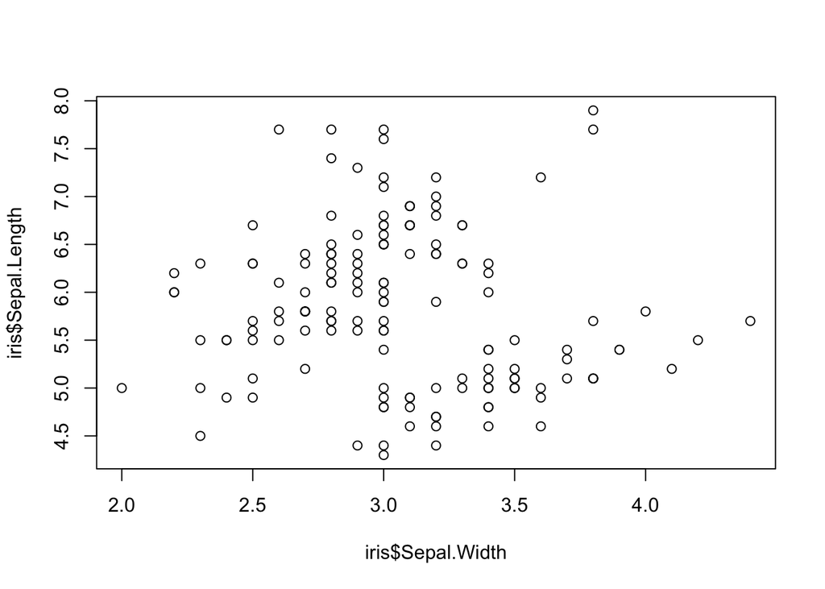

```r
library(datasets) #lets use iris
plot(iris$Sepal.Width, iris$Sepal.Length)
```

The relationship doesn’t look that linear, but let’s try it anyway and look at the residual vs. fitted plot

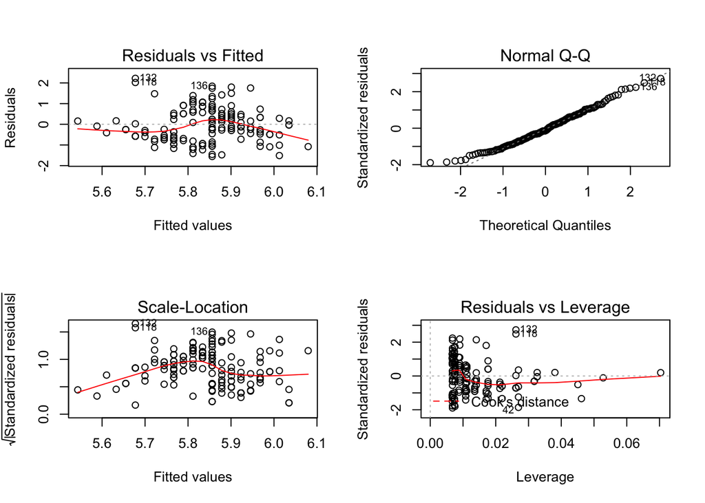

```r
iris_lm <- lm(Sepal.Length ~ Sepal.Width, data = iris)

par(mfrow=c(2,2))
plot(iris_lm)
```

**YIKES!** The data are normally distributed, but there are some problems with the assumption of linearity between Y and X.

## 1.2 What can you do about it?

- Add interaction terms
- Add more explanatory variables
- Expand the model by adding a non-linear main effect (like $x^{2}$)
- You could transform the variables to linearize the relationship (either response or explanatory). However, transformation affects the entire Y-X relationship, whereas maybe the relationship is partly linear and also partly non-linear along the X gradient

What if you have exhausted these options and don’t want to transform? One option is to use smoothing models or **GAM**

# 2.1 Things to keep in mind when fitting GAMs

- We want an arbitrary smooth curve to relate **Y** to **X**
- We can construct such a curve by **adding** together many simpler curves
- To control for the underfitting-overfitting tradeoff, we allow the smoother to have a large number of components (i.e., many curves or splines), but we control for the wiggliness of the curve using a penalty term $\lambda$
- The optimal penalty term is chosen as part of the fitting process via **generalized cross-validation**

# 3.1 Fitting GAMs with mgcv

- *the* choice for running GAMs in R
- “There are as many smoothing techniques as there are roads to Rome” - Zurr 2009
- mgcv estimates smoothers using thin plate regression splines (default)

```r
library(mgcv)
```

## 3.2 Basic Syntax

**Fitting a GAM is similar to fitting a GLM but use `s(x)` instead of `x`** - This syntax tells the function to fit a smoother to the predictor `Sepal.Width`

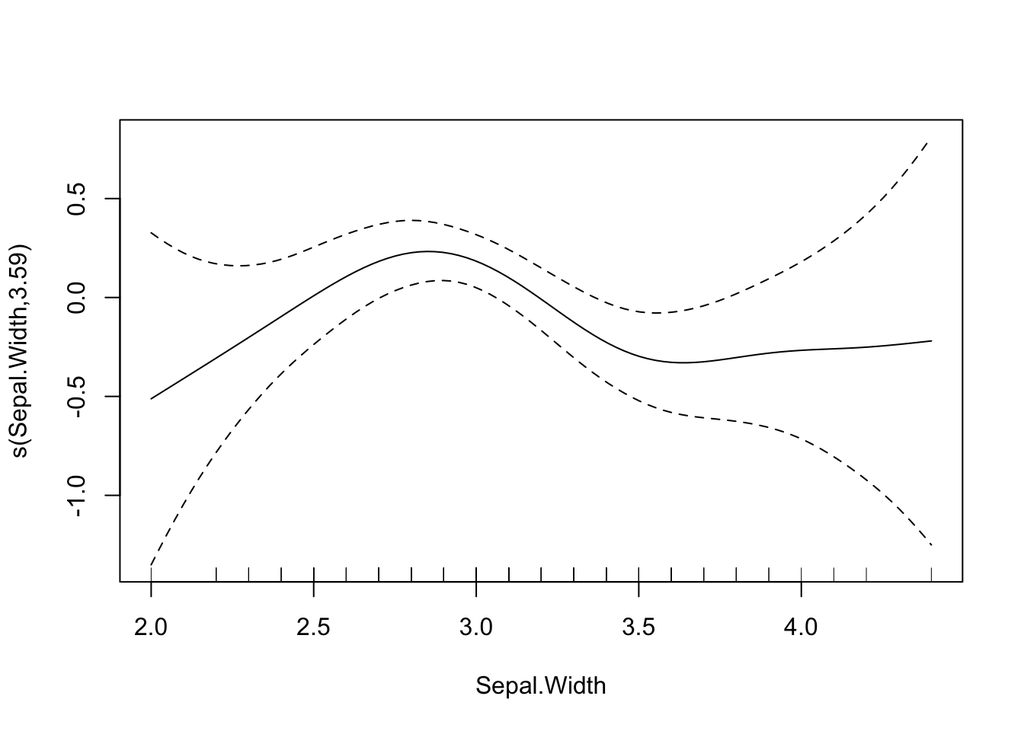

```r
iris_gam <- gam(Sepal.Length ~ s(Sepal.Width), data = iris)
plot(iris_gam)
```

## 3.3 Model Summary

- Default family is gaussian (but it can be specified with an argument `family` (e.g., `family = poisson()`). Check out `family.mcgv` for a full list of what’s available in this package

**The output has two sections:**

1. List of estimates for any parametric (i.e., not smoothed) predictors. These can be continuous predictors that are not smoothed or factors (e.g., `Species`)
2. List of smoothed terms - in this case `s(Sepal.Width)`
- The **edf** is the “estimated degrees of freedom” and basically is using the wiggliness of the smoother to say “if this smoother were written as a parametric equation, this is approximately how many parameters that equation would.” Or the number of splines. Shown in y-axis label.
- **F**-statistic comes from the approximate F-test for how well variation in Y is explained by the smoother. In this case, significant variation is explained by the smoother
- **Deviance explained** is measure of how well the curve explains the data, its equivalent to the unadjusted $R^{2}$ but for non-Gaussian families, this metric is preffered over $R^{2}$
- **GCV**,or generalized cross validation score, can be taken as an estimate of the mean square prediction error based on a leave-one-out cross validation estimation process. A lower score is better because it means less predictive error.

```r
summary(iris_gam)
```

```
##
## Family: gaussian
## Link function: identity
##
## Formula:
## Sepal.Length ~ s(Sepal.Width)
##
## Parametric coefficients:
##             Estimate Std. Error t value Pr(>|t|)
## (Intercept)  5.84333    0.06524   89.56   <2e-16 ***
## ---
## Signif. codes:  0 '***' 0.001 '**' 0.01 '*' 0.05 '.' 0.1 ' ' 1
##
## Approximate significance of smooth terms:
##                  edf Ref.df     F p-value
## s(Sepal.Width) 3.592  4.505 2.635   0.032 *
## ---
## Signif. codes:  0 '***' 0.001 '**' 0.01 '*' 0.05 '.' 0.1 ' ' 1
##
## R-sq.(adj) =  0.0688   Deviance explained = 9.13%
## GCV = 0.65866  Scale est. = 0.6385    n = 150
```

## 3.4 Plotting smoother with partial residuals

- Partial residuals are the calculated for each observation as the predicted value from the smoother function plus the residual
- Useful for asking “What is the efect of predictor `X` while accounting for any variation explained by the other predictors in the model?”
- As a final step for plotting, if we want the fitted relationship on the scale of the raw data, we can add the intercept back to the plot (second panel)

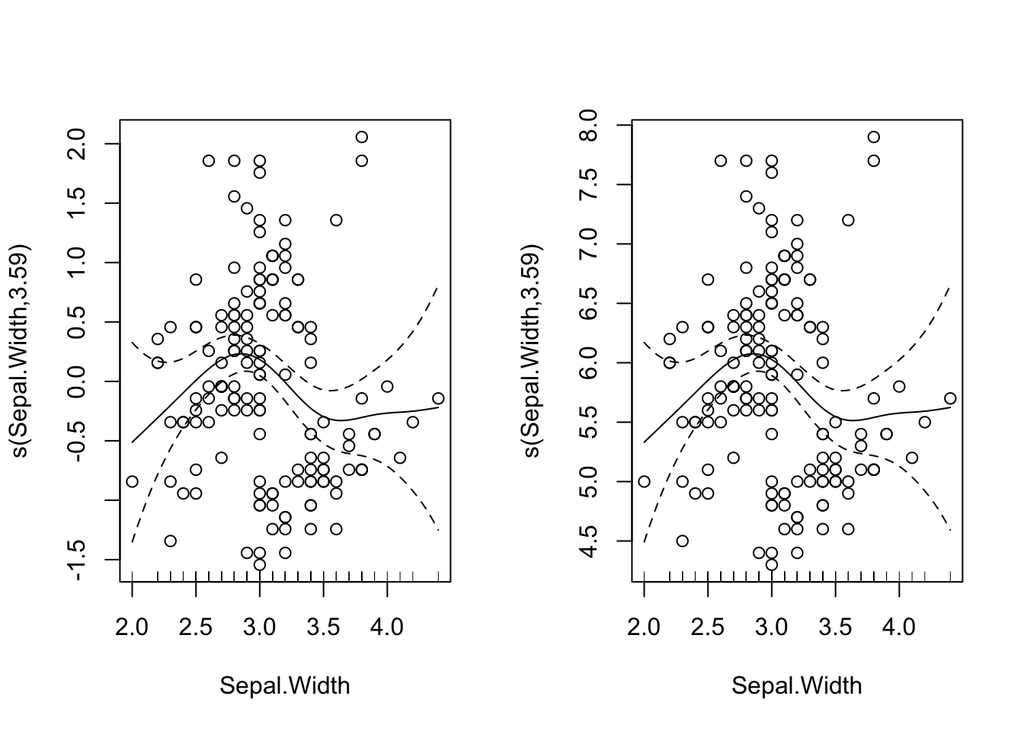

```r
par(mfrow=c(1,2))
plot(iris_gam, residuals = TRUE, pch = 21)
plot(iris_gam, residuals = TRUE, pch = 21, shift = coef(iris_gam)[1])
```

## 3.5 Using `gam.check()` for residual diagnostics

- Plots in the left column give a sense for whether the deviance residuals are normally distributed
- Plots on the right give a sense for whether the variance is homoscedastic (homogeneity of variance)

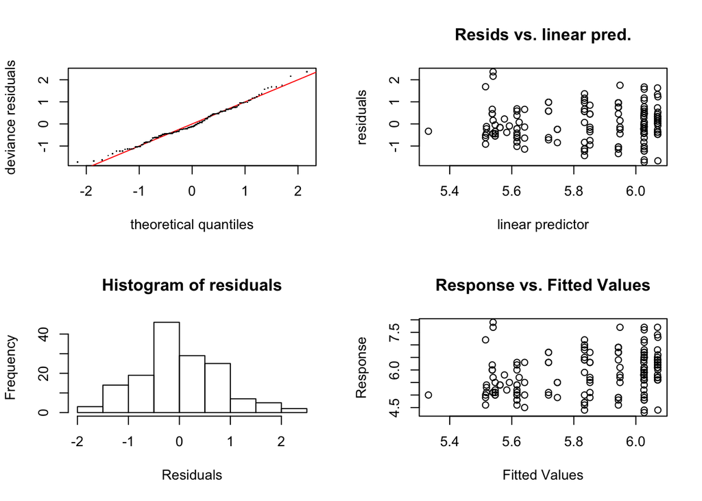

```
##
## Method: GCV   Optimizer: magic
## Smoothing parameter selection converged after 4 iterations.
## The RMS GCV score gradient at convergence was 9.424113e-08 .
## The Hessian was positive definite.
## Model rank =  10 / 10
##
## Basis dimension (k) checking results. Low p-value (k-index<1) may
## indicate that k is too low, especially if edf is close to k'.
##
##                  k'  edf k-index p-value
## s(Sepal.Width) 9.00 3.59    0.64  <2e-16 ***
## ---
## Signif. codes:  0 '***' 0.001 '**' 0.01 '*' 0.05 '.' 0.1 ' ' 1
```

```r
par(mfrow=c(2,2))
gam.check(iris_gam)
```

## 3.6 You can also use DHARMa

- Simulation-based approach to create easily interpretable scaled (quantile) residuals for many types of models. It is compatible with GAM models constructed with `mgcv`

```r
#load package
library(DHARMa)
```

### 3.6.1 Run simulation

- No problems detected here
- Check it out here: [DHARMa Workflow](https://cran.r-project.org/web/packages/DHARMa/vignettes/DHARMa.html#workflow-in-dharma)

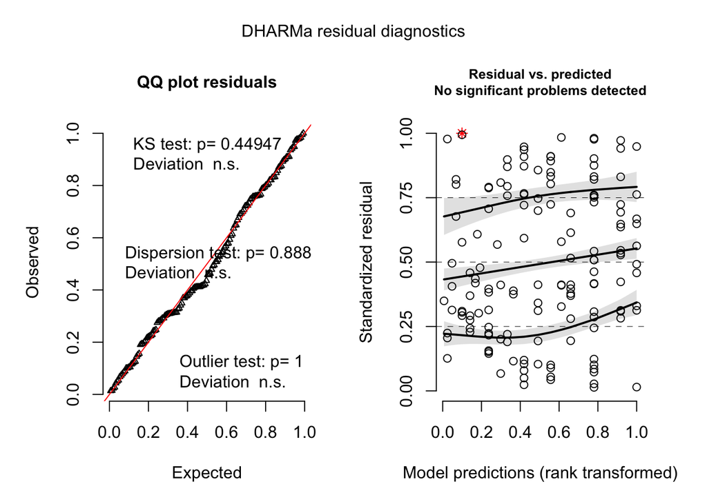

```r
simulationOutput <- simulateResiduals(fittedModel = iris_gam, plot = T)
```

# 4.1 Customize the model

- `gam` default settings usually work fairly well
- We have let the function automate everything involved in fitting the smoother
- automatically decides how many knots in the spline
- choses optimal penalty for wiggliness using GCV
  - **Too smooth**: might miss patterns in the data
  - **Too wiggly**: might fit subtle or random patterns that reduce predictive performance

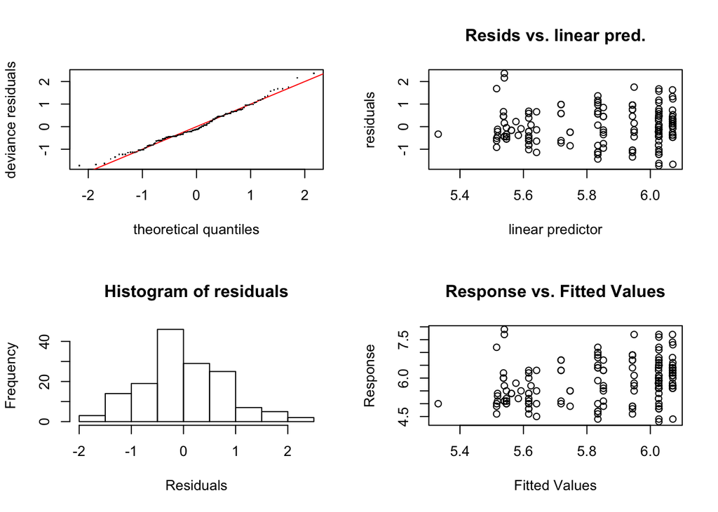

```
##
## Method: GCV   Optimizer: magic
## Smoothing parameter selection converged after 4 iterations.
## The RMS GCV score gradient at convergence was 9.424113e-08 .
## The Hessian was positive definite.
## Model rank =  10 / 10
##
## Basis dimension (k) checking results. Low p-value (k-index<1) may
## indicate that k is too low, especially if edf is close to k'.
##
##                  k'  edf k-index p-value
## s(Sepal.Width) 9.00 3.59    0.64  <2e-16 ***
## ---
## Signif. codes:  0 '***' 0.001 '**' 0.01 '*' 0.05 '.' 0.1 ' ' 1
```

```r
par(mfrow=c(2,2))
gam.check(iris_gam)
```

## 4.2 Modifying smoother complexity

- **Output**: k’ is the upper bound on the complexity/wiggliness of the smoother (~ number of knots). During the model optimization process,the function automatically decides the maximum complexity (k’) and then it choses the optiaml penalty for wiggliness ($\lambda$) using the GCV. This results in the optimized number of spines and is shown as the estimated degrees of freedom (**edf**). Here it was reduced to 3.59 (less complex smoother).
- If **k’** is close to the **edf** then maybe the function did not permit enough complexity to begin with, so we can set k ourselves

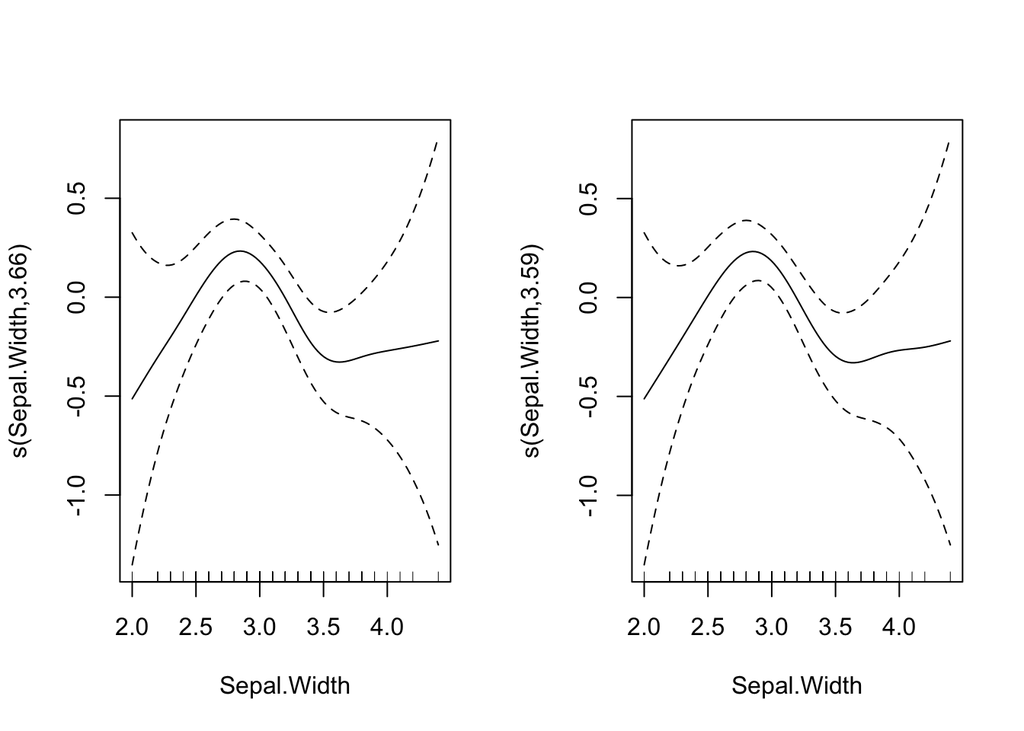

```r
iris_gam_k18 <- gam(Sepal.Length ~ s(Sepal.Width, k = 18), data = iris)

par(mfrow=c(1,2))
plot(iris_gam_k18)
plot(iris_gam)
```

The results look very smiliar which is good! That means that the default settings allowed for enough complexity according to the cross-validation criterion (see the similar **edf** values on the y-axis). This means that, through the cross-validation process, the “wiggliness” was penalized to a similar degree and resulted in the same number of splines.

**What if the smoother was not penalized for wiggliness?** - we can force this to be the case by setting `fx = TRUE`

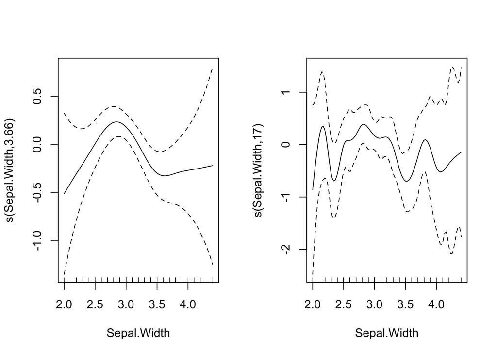

```r
iris_gam_k18_fxT <- gam(Sepal.Length ~ s(Sepal.Width, k = 18, fx = TRUE), data = iris)

par(mfrow=c(1,2))
plot(iris_gam_k18)
plot(iris_gam_k18_fxT)
```

## 4.3 Compare model summaries

- `iris_gam` has the optimal number of splines to have the lowest GCV score
- GCV score for `iris_gam_k18_fxT` is higher
- this curve over-fits the data

```r
summary(iris_gam)
```

```
##
## Family: gaussian
## Link function: identity
##
## Formula:
## Sepal.Length ~ s(Sepal.Width)
##
## Parametric coefficients:
##             Estimate Std. Error t value Pr(>|t|)
## (Intercept)  5.84333    0.06524   89.56   <2e-16 ***
## ---
## Signif. codes:  0 '***' 0.001 '**' 0.01 '*' 0.05 '.' 0.1 ' ' 1
##
## Approximate significance of smooth terms:
##                  edf Ref.df     F p-value
## s(Sepal.Width) 3.592  4.505 2.635   0.032 *
## ---
## Signif. codes:  0 '***' 0.001 '**' 0.01 '*' 0.05 '.' 0.1 ' ' 1
##
## R-sq.(adj) =  0.0688   Deviance explained = 9.13%
## GCV = 0.65866  Scale est. = 0.6385    n = 150
```

```r
summary(iris_gam_k18_fxT)
```

```
##
## Family: gaussian
## Link function: identity
##
## Formula:
## Sepal.Length ~ s(Sepal.Width, k = 18, fx = TRUE)
##
## Parametric coefficients:
##             Estimate Std. Error t value Pr(>|t|)
## (Intercept)  5.84333    0.06621   88.25   <2e-16 ***
## ---
## Signif. codes:  0 '***' 0.001 '**' 0.01 '*' 0.05 '.' 0.1 ' ' 1
##
## Approximate significance of smooth terms:
##                edf Ref.df     F p-value
## s(Sepal.Width)  17     17 1.375   0.159
##
## R-sq.(adj) =  0.041   Deviance explained =   15%
## GCV = 0.74725  Scale est. = 0.65758   n = 150
```

# 5.1 Interaction between a smoother and a factor

```r
iris_gam2 <- gam(Sepal.Length ~ Species + s(Sepal.Width, by = Species), data = iris)
summary(iris_gam2)
```

```
##
## Family: gaussian
## Link function: identity
##
## Formula:
## Sepal.Length ~ Species + s(Sepal.Width, by = Species)
##
## Parametric coefficients:
##                   Estimate Std. Error t value Pr(>|t|)
## (Intercept)        4.75006    0.08579   55.37   <2e-16 ***
## Speciesversicolor  1.43451    0.11946   12.01   <2e-16 ***
## Speciesvirginica   1.95875    0.11694   16.75   <2e-16 ***
## ---
## Signif. codes:  0 '***' 0.001 '**' 0.01 '*' 0.05 '.' 0.1 ' ' 1
##
## Approximate significance of smooth terms:
##                                   edf Ref.df      F  p-value
## s(Sepal.Width):Speciessetosa     1.00  1.000 18.025 3.86e-05 ***
## s(Sepal.Width):Speciesversicolor 1.00  1.000 19.388 2.04e-05 ***
## s(Sepal.Width):Speciesvirginica  4.06  4.788  6.026 7.97e-05 ***
## ---
## Signif. codes:  0 '***' 0.001 '**' 0.01 '*' 0.05 '.' 0.1 ' ' 1
##
## R-sq.(adj) =  0.728   Deviance explained = 74.3%
## GCV = 0.19821  Scale est. = 0.18624   n = 150
```

All of the smoothers are significant, lets see what they look like among species:

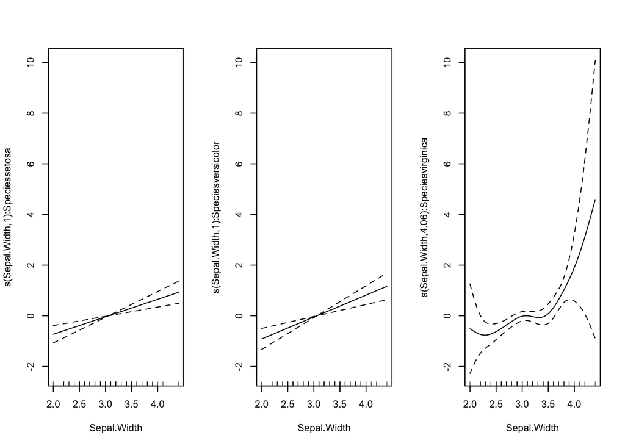

```r
par(mfrow=c(1,3))
plot(iris_gam2)
```

Next we want to know whether a given species differs from the overall relationship fit by the first smoother `s(Sepal.Width)`. The code below will also give a set of plots that show us if the smoother fit for virginica differs from the overall relationship fit by the first smoother. **This is useful if you want to *quantify* how smoothers differ among groups**

```r
iris_gam3 <- gam(Sepal.Length ~ Species + s(Sepal.Width) + s(Sepal.Width, by = as.numeric(Species == "virginica")), data = iris)
summary(iris_gam3)
```

```
##
## Family: gaussian
## Link function: identity
##
## Formula:
## Sepal.Length ~ Species + s(Sepal.Width) + s(Sepal.Width, by = as.numeric(Species ==
##     "virginica"))
##
## Parametric coefficients:
##                   Estimate Std. Error t value Pr(>|t|)
## (Intercept)        4.72374    0.07663  61.647   <2e-16 ***
## Speciesversicolor  1.43106    0.11925  12.000   <2e-16 ***
## Speciesvirginica   0.51869    1.01565   0.511     0.61
## ---
## Signif. codes:  0 '***' 0.001 '**' 0.01 '*' 0.05 '.' 0.1 ' ' 1
##
## Approximate significance of smooth terms:
##                                                     edf Ref.df      F  p-value
## s(Sepal.Width)                                    1.000   1.00 37.005 8.72e-09
## s(Sepal.Width):as.numeric(Species == "virginica") 4.387   5.15  1.517    0.215
##
## s(Sepal.Width)                                    ***
## s(Sepal.Width):as.numeric(Species == "virginica")
## ---
## Signif. codes:  0 '***' 0.001 '**' 0.01 '*' 0.05 '.' 0.1 ' ' 1
##
## Rank: 21/22
## R-sq.(adj) =  0.729   Deviance explained = 74.1%
## GCV = 0.19625  Scale est. = 0.18593   n = 150
```

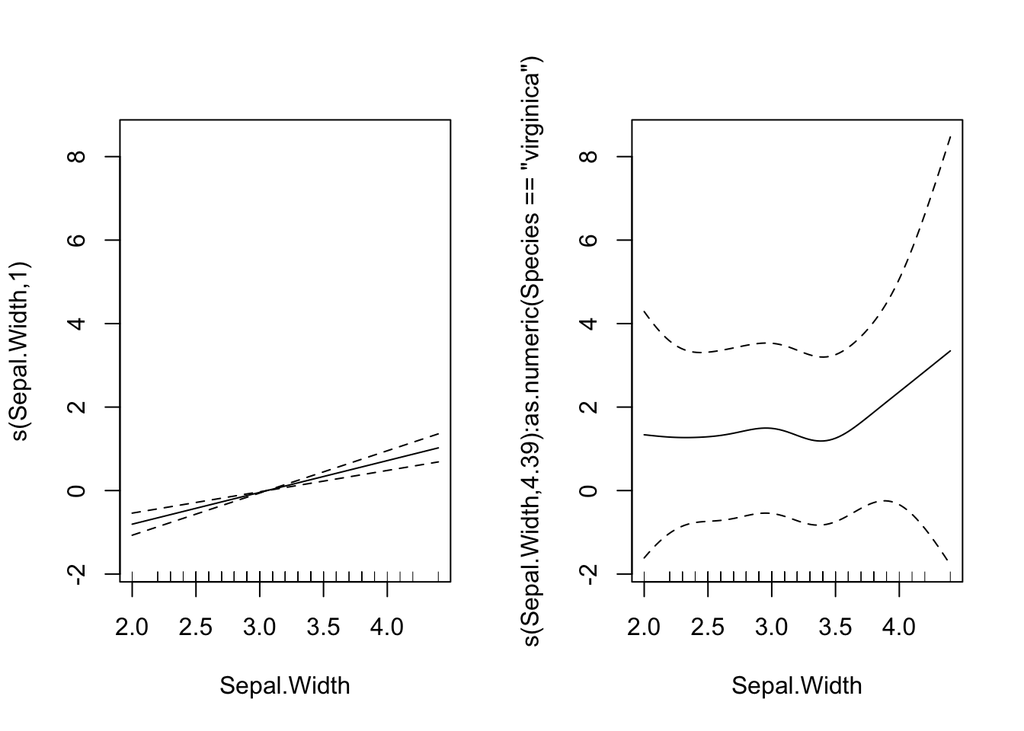

```r
par(mfrow=c(1,2))
plot(iris_gam3)
```

1. The first graph shows the smoother for `Sepal.width` after we account for species (which becomes linear, see the edf on the y-axis, which is 1).
2. The second graph shows us how the smoother for virginica differs from the overall smoother. Values on the y-axis indicate how different is from the overall relationship. Values of 0 indicate no difference. You can see that the relationship between `Sepal.width` and `Sepal.length` in *Iris virginica* deviate from the overall relationship most at large values of `Sepal.Width`; however, differences between virginica and the overall relationship across the range of `Sepal.width` include 0 in the standard error. **This indicates that smoother for virginica is not significantly different from the overall smoother (after accounting for variation due to `Species`)**

# 6.1 Comparing models with AIC(c)

GAM models can be compared using AIC just like GLMs

```r
AIC(iris_gam) #just one predictor s(Sepal.width)
```

```
## [1] 364.9064
```

```r
AIC(iris_gam2) #includes species as a parametric variable (Species) and smooth variable (s(Sepal.))
```

```
## [1] 184.3487
```